# HW2

Author

Yufan Li

## Homework 2

Github Repo Link: https://github.com/YufanLi2002/STATS506.git

### Problem 1 - Dice Game

**Let’s play a dice game. It costs $2 to play. You roll a single 6-sided die.**

- **On a roll of 3 or 5, you win twice your roll.**
- **On any other roll, you lose.**

**The input and output should be:**

- **Input: The number of dice to roll.**
- **Output: Total winnings**

**a.**

- **Version 1: Implement this game using a loop.**
- **Version 2: Implement this game using built-in R vectorized functions.**
- **Version 3: Implement this by rolling all the dice into one and collapsing the die rolls into a single `table()`. (Hint: Be careful indexing the table - what happens if you make a table of a single dice roll? You may need to look to other resources for how to solve this.)**
- **Version 4: Implement this game by using one of the “`apply`” functions.**

Version 1

```r
#' Vesion 1 of dice game
#' Implement this game using a loop
#'
#' Rules:
#' It costs $2 to play the game
#' On a roll of 3 or 5, you win twice your roll; On any other roll, you lose
#'
#' @param n # the number of dice to roll
#' @return # total winnings
#'
#' @examples
#' play_dice(1) returns 4
#'
#' @export
#'
#'
play_dice1 <- function(n){
  cost = 2 * n         # stores the total cost of all dices
  total_win = 0        # initialize total_win to 0
  for (i in 1:n){      # using a for loop to loop through all dice rolls
    nsim <- sample(1:6, 1, replace = TRUE)

  # use the sample() function to generate each roll one-by-one ramdomly (1 to 6)
    if (nsim == 3 || nsim == 5){
      total_win = total_win + 2 * nsim
      # if roll is 3, add 6 to total win, if roll is 5, add 10 to total win
    }
  }
  return(total_win - cost)
  # return total winning minus the cost to play game
}
#play_dice1(3000)
```

Version 2

```r
#' Vesion 2 of dice game
#' Implement this game using built-in R vectorized functions
#'
#' Rules:
#' It costs $2 to play the game
#' On a roll of 3 or 5, you win twice your roll; On any other roll, you lose
#'
#' @param n # the number of dice to roll
#' @return # total winnings
#'
#' @examples
#' play_dice(1) returns 4
#'
#' @export
play_dice2 <- function(n){
  cost = 2 * n
  nsim <- sample(1:6, n, replace = TRUE)
  # use the built-in function sample() to generate all n rolls as a vector ramdomly (1 to 6)

  win_vec = ifelse(nsim == 3 | nsim == 5, 2 * nsim, 0)
  # if the simuation of roll is equal to 3 or 5, then times itself twice, otherwise return 0

  total_win = sum(win_vec) - cost
  ## total win equals the sum of the vector computed above - cost

  return(total_win)
}
#play_dice2(10)
```

Version 3

```r
#' Vesion 3 of dice game
#' Implement this game by rolling all the dice into one and collapsing the
#' die rolls into a single table()
#'
#' Rules:
#' It costs $2 to play the game
#' On a roll of 3 or 5, you win twice your roll; On any other roll, you lose
#'
#' @param n # the number of dice to roll
#' @return # total winnings
#'
#' @examples
#' play_dice(1) returns 4
#'
#' @export
play_dice3 <- function(n){
  cost = 2 * n
  nsim <- sample(1:6, n, replace = TRUE)
  # use sample() to generate all n rolls as a vector ramdomly (1 to 6)

  roll_table = table(factor(nsim, levels = 1:6))  # Ensures 1 to 6 are always in the table
  counts = as.numeric(roll_table)                 # convert to numeric
  total_win = (2 * 3 * counts[3]) +               # Winnings from rolling 3
              (2 * 5 * counts[5])                 # Winnings from rolling 5
  return(total_win - cost)
}
# play_dice3(10)
```

Version 4

```r
#' Vesion 4 of dice game
#' Implement this game by by using one of the “apply” functions.
#'
#' Rules:
#' It costs $2 to play the game
#' On a roll of 3 or 5, you win twice your roll; On any other roll, you lose
#'
#' @param n # the number of dice to roll
#' @return # total winnings
#'
#' @examples
#' play_dice(1) returns 4
#'
#' @export
play_dice4 <- function(n) {
  rolls <- sample(1:6, n, replace = TRUE)
  # use sample() to generate all n rolls as a vector ramdomly (1 to 6)

  winnings <- sapply(rolls, function(roll) {
    ## Using the sapply function for the vector of rolls

    if (roll == 3 || roll == 5) { ## Implement rules of the game
      return(roll * 2)
    } else {
      return(0)
    }
  })

  total_winnings <- sum(winnings) - n * 2

  ## Return total winning
  return(total_winnings)
}

# play_dice4(10)
```

**b. Demonstrate that all versions work. Do so by running each a few times, once with an input a 3, and once with an input of 3,000.**

```r
## Demonstrate all versions work with input 3 and 3000
play_dice1(3)
```

```
[1] 0
```

```r
play_dice2(3)
```

```
[1] -6
```

```r
play_dice3(3)
```

```
[1] 0
```

```r
play_dice4(3)
```

```
[1] -6
```

```r
play_dice1(3000)
```

```
[1] 2148
```

```r
play_dice2(3000)
```

```
[1] 2220
```

```r
play_dice3(3000)
```

```
[1] 1858
```

```r
play_dice4(3000)
```

```
[1] 2000
```

All versions work after running multiple times with an input of 3 and 3000.

**c. Demonstrate that the four versions give the same result. Test with inputs 3 and 3,000. (You will need to add a way to control the randomization.)**

```r
## All four vesions give the same result, tested with 3 and 3000.
## Using set.seed() function to control randomization
set.seed(506)
play_dice1(3)
```

```
[1] 6
```

```r
set.seed(506)
play_dice2(3)
```

```
[1] 6
```

```r
set.seed(506)
play_dice3(3)
```

```
[1] 6
```

```r
set.seed(506)
play_dice4(3)
```

```
[1] 6
```

```r
set.seed(506)
play_dice1(3000)
```

```
[1] 1974
```

```r
set.seed(506)
play_dice2(3000)
```

```
[1] 1974
```

```r
set.seed(506)
play_dice3(3000)
```

```
[1] 1974
```

```r
set.seed(506)
play_dice4(3000)
```

```
[1] 1974
```

Using the set.see() function in R to ensure that all four versions return the same results.

**d. Use the *microbenchmark* package to clearly demonstrate the speed of the implementations. Compare performance with a low input (1,000) and a large input (100,000). Discuss the results**

```r
library(microbenchmark)
# Benchmarking with 1,000 rolls
benchmark_1000 <- microbenchmark(
  ver1 = play_dice1(1000),
  ver2 = play_dice2(1000),
  ver3 = play_dice3(1000),
  ver4 = play_dice4(1000),
  times = 10 # Repeat runs 10 times
)
print(benchmark_1000)
```

```
Unit: microseconds
 expr      min       lq      mean    median       uq      max neval
 ver1 3698.250 3843.626 4105.7090 3884.6465 4014.418 6089.084    10
 ver2  111.751  115.876  121.7840  120.3545  125.084  143.709    10
 ver3  105.417  107.001  123.1880  116.0005  124.875  168.292    10
 ver4  403.084  410.834  425.1592  411.5215  420.418  489.167    10
```

```r
# Benchmarking with 100,000 rolls
benchmark_100000 <- microbenchmark(
  ver1 = play_dice1(100000),
  ver2 = play_dice2(100000),
  ver3 = play_dice3(100000),
  ver4 = play_dice4(100000),
  times = 10 # Repeat runs 10 times
)
print(benchmark_100000)
```

```
Unit: milliseconds
 expr        min         lq       mean     median         uq        max neval
 ver1 378.228000 381.587876 394.400480 394.578063 400.424626 423.610917    10
 ver2   9.466417  10.065251  10.246934  10.411334  10.449334  10.801084    10
 ver3   6.314667   6.398709   6.862338   6.873667   7.313084   7.495209    10
 ver4  42.788543  43.755334  45.522096  44.946417  46.703792  51.966917    10
```

With a thorough examination for both outputs, we can see that the loop implementation is consistently the slowest across all input sizes, making it unsuitable for larger datasets. And the `apply()` implementation is moderately efficient but not as fast as vectorized methods.

**e. Do you think this is a fair game? Defend your decision with evidence based upon a Monte Carlo simulation.**

```r
# Monte Carlo Simulation of the Dice Game
#'
#' @param n_simulations ## number of simulations
#'
#' @return The expected value of the net outcome
#'
#' @examples monte_carlo_simulation(1000000) returns 0.67
#'
#' @export
monte_carlo_simulation <- function(n_simulations) {
  rolls <- sample(1:6, n_simulations, replace = TRUE)
  # use sample() to generate all n rolls as a vector ramdomly (1 to 6)

  # Calculate the winnings
  winnings <- ifelse(rolls == 3 | rolls == 5, rolls * 2, 0)

  # Calculate net outcome (winnings minus the $2 cost per game)
  net_outcome <- winnings - 2

  # Return the average net outcome (expected value)
  expected_value <- mean(net_outcome)

  return(expected_value)
}

# Running the Monte Carlo simulation with 1000000 games
monte_carlo_simulation(1000000)
```

```
[1] 0.667902
```

I do not think this is a fair game. Based on the probability theory, the chance of losing is $\frac{4}{6}$ (when outcome is 1,2,4,6), and the probability of winning is $\frac{2}{6}$ =$\frac{1}{3}$ (when outcome is 3,5). Therefore the expected value of the game given the condition of the rules is calculated as: $\frac{1}{6}\cdot\left(6-2\ \right)+\ \frac{1}{6}\cdot\left(10-2\right)\ +\ \frac{4}{6}\cdot\left(-2\right)\ =\ \frac{2}{3}$ which is approximately 0.66667. Based on the implementation of the Monte Carlo Algorithm, we can actually observe that. When we run the simulation 1000000 times, the expected value is shown to be approximately 0.66 as well. This implies the game is actually favorable to the player, and on average, they make a profit of $0.67 per game due to the high payouts of winning.

### Problem 2 - Linear Regression

**a. The names of the variables in this data are way too long. Rename the columns of the data to more reasonable lengths.**

```r
library(dplyr)
setwd("~/Documents/GitHub/STATS506/HW2")
data <- read.csv("cars.csv")
car <- data %>%
  ## Using dplyr package to compute data manipulation
  rename(Height = Dimensions.Height,
         Length = Dimensions.Length,
         Width = Dimensions.Width,
         Driveline = Engine.Information.Driveline,
         EngineType = Engine.Information.Engine.Type,
         Hybrid = Engine.Information.Hybrid,
         Gears = Engine.Information.Number.of.Forward.Gears,
         Transmission = Engine.Information.Transmission,
         CityFuel = Fuel.Information.City.mpg,
         FuelType = Fuel.Information.Fuel.Type,
         HighwayFuel = Fuel.Information.Highway.mpg,
         Classification = Identification.Classification,
         ID = Identification.ID,
         Make = Identification.Make,
         ModelYear = Identification.Model.Year,
         Year = Identification.Year,
         Horsepower = Engine.Information.Engine.Statistics.Horsepower,
         Torque = Engine.Information.Engine.Statistics.Torque
         ) ## Renaming all the variables
```

**b. Restrict the data to cars whose Fuel Type is “Gasoline”.**

```r
# filter the data to cars whose Fuel Type is Gasoline
car <- car%>%filter(FuelType == "Gasoline")
```

**c. Examine the distribution of highway gas mileage. Consider whether a transformation could be used. If so, generate the transformed variable and *use this variable going forward*. If not, provide a short justification.**

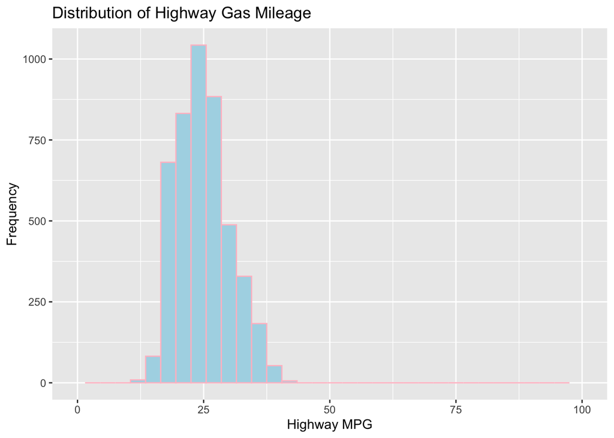

```r
library(ggplot2)
# Create a histogram for examination of the data using ggplot2 package
ggplot(car, aes(x = HighwayFuel)) +
  geom_histogram(binwidth = 3, fill = "lightblue", color = "pink") +
  # picked a reasonable binwidth to demonstrate the distribution better
  labs(title = "Distribution of Highway Gas Mileage",
       x = "Highway MPG", y = "Frequency")+
  xlim(0,100)
```

```r
  ## Set the limit of x-axis to be (0,100), removing potential outliers from plot

## use summary() to analyze the data
summary(car$HighwayFuel)
```

```
   Min. 1st Qu.  Median    Mean 3rd Qu.    Max.
  13.00   21.00   25.00   24.97   28.00  223.00
```

Based on the output of the summary of the Highway MPG, we can observe that there is potential outliers in the data set since the max number is 223. And by looking at the distribution of the Highway MPG histogram plotted above, we can see that the data is slightly right-skewed. Therefore, A log transformation could be used here to normalize the data, making it more suitable for analysis.

```r
# Apply log transformation to HighwayFuel
car <- car %>%
  mutate(Log_HighwayFuel = log(HighwayFuel))

# Check for transformation results
summary(car$Log_HighwayFuel)
```

```
   Min. 1st Qu.  Median    Mean 3rd Qu.    Max.
  2.565   3.045   3.219   3.194   3.332   5.407
```

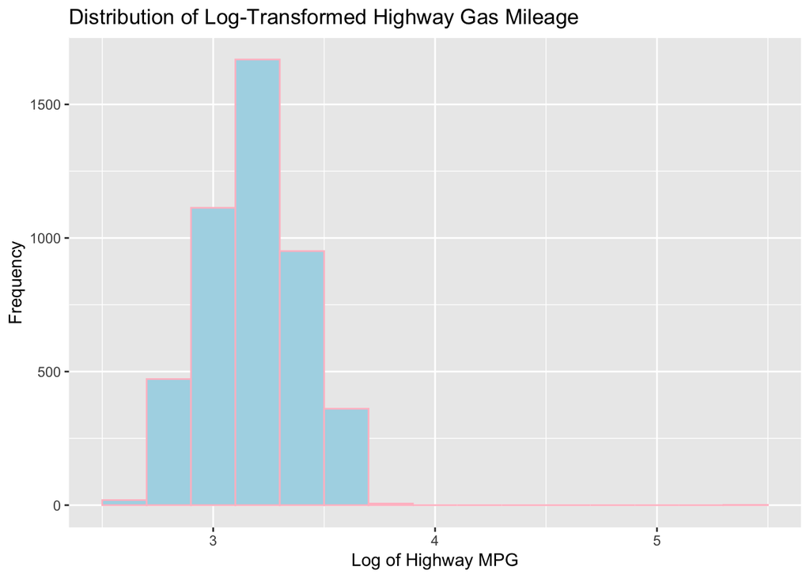

```r
# Plot histogram of log-transformed HighwayFuel
ggplot(car, aes(x = Log_HighwayFuel)) +
  geom_histogram(binwidth = 0.2, fill = "lightblue", color = "pink") +
  labs(title = "Distribution of Log-Transformed Highway Gas Mileage",
       x = "Log of Highway MPG", y = "Frequency")
```

After the log-transformation, we can see that the data become more normalized based on the histogram above showing its distribution.

**d. Fit a linear regression model predicting MPG on the highway. The predictor of interest is torque. Control for:**

- **The horsepower of the engine**
- **All three dimensions of the car**
- **The year the car was released, as a categorical variable.**

**Briefly discuss the estimated relationship between torque and highway MPG. Be precise about the interpretation of the estimated coefficient.**

```r
# Convert 'Year' to a categorical variable (factor)
car$Year <- as.factor(car$Year)

# Fit the linear regression model
model <- lm(Log_HighwayFuel ~ Torque + Horsepower + Height + Length + Width + Year, data = car)

# Summary of the regression model
summary(model)
```

```
Call:
lm(formula = Log_HighwayFuel ~ Torque + Horsepower + Height +
    Length + Width + Year, data = car)

Residuals:
     Min       1Q   Median       3Q      Max
-0.54759 -0.09385 -0.00414  0.09894  2.41852

Coefficients:
              Estimate Std. Error t value Pr(>|t|)
(Intercept)  3.507e+00  2.216e-02 158.236  < 2e-16 ***
Torque      -2.294e-03  6.757e-05 -33.956  < 2e-16 ***
Horsepower   9.238e-04  6.984e-05  13.227  < 2e-16 ***
Height       4.050e-04  3.456e-05  11.719  < 2e-16 ***
Length       3.475e-05  2.710e-05   1.282  0.19980
Width       -8.722e-05  2.774e-05  -3.144  0.00168 **
Year2010    -2.181e-02  2.076e-02  -1.051  0.29342
Year2011    -2.430e-03  2.072e-02  -0.117  0.90665
Year2012     4.012e-02  2.089e-02   1.921  0.05485 .
---
Signif. codes:  0 '***' 0.001 '**' 0.01 '*' 0.05 '.' 0.1 ' ' 1

Residual standard error: 0.1412 on 4582 degrees of freedom
Multiple R-squared:  0.5638,    Adjusted R-squared:  0.563
F-statistic: 740.3 on 8 and 4582 DF,  p-value: < 2.2e-16
```

**e. It seems reasonable that there may be an interaction between torque and horsepower. Refit the model (with `lm`) and generate an interaction plot, showing how the relationship between torque and MPG changes as horsepower changes. Choose reasonable values of torque, and show lines for three different reasonable values of horsepower.**

**(Hint: If you choose to use the *interactions* package for this, look at the `at =` argument to help with how year comes into play - choose a reasonable single value for year.**

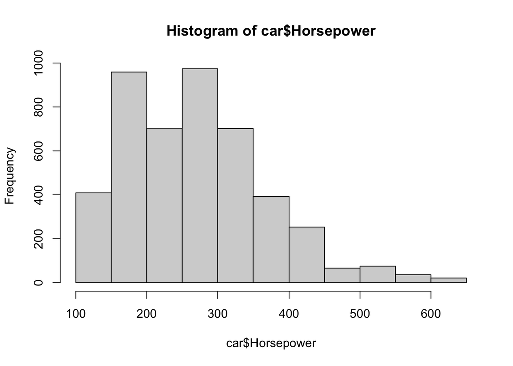

```r
## Import 2 libraries that can be used for interaction plot
library(emmeans)
library(interactions)
## fit model with interaction Torque * Horsepower
model_interaction <- lm(Log_HighwayFuel ~ Torque * Horsepower + Height + Length + Width + Year,
                        data = car)

## Analyze the histogram of both torque and horsepower to pick the three reasonable values
## for both torque and horsepower, based on the result, horsepower is centered around the
## range (200, 400), therefore, I picked 3 values around its Q1 and Q3 quantile values
## since the majority of the data points falls in this range
hist(car$Horsepower)
```

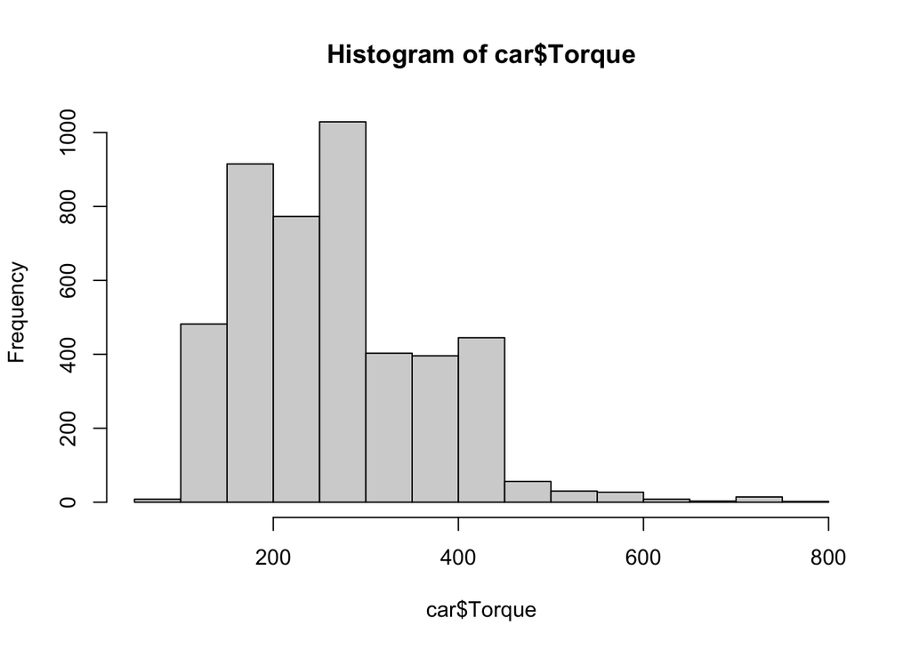

```r
hist(car$Torque)
```